# Credit Card Fraud Detection Tool

Akash Sukhija (sukhija4@illinois.edu)

18th November 2020

## Abstract

> Introduction: Gives a Brief Overview of the Project

> Methods : Discusses about the Data, Various Preprocessing Techniques, and the different Models under consideration

> Results : Exhibits the result of the models experimented in the Methods section

> Discussion: States the best model that can be used and the vitality of the results.

## Introduction

With the advent of cashless transactions, it is important that customers don’t get charged for transactions not willfully initiated by them. Fraudulent transactions are a menace and there are countless instances where customers are tricked into making transactions via social engineering or unknowingly by using RFID. As part of this project I plan to use machine learning techniques to determine fraudulent transactions as most of them have a certain pattern. The dataset contains transactions made by credit cards in September 2013 by european cardholders.

#### Perforing a Univariate Analysis on the data using the skimr package to understand the different types of variables and their characteristics:

Data summary

| Name | cc_sub |
| --- | --- |
| Number of rows | 25000 |
| Number of columns | 31 |
| _______________________ |  |
| Column type frequency: |  |
| character | 1 |
| numeric | 30 |
| ________________________ |  |
| Group variables | None |

**Variable type: character**

| skim_variable | n_missing | complete_rate | min | max | empty | n_unique | whitespace |
| --- | --- | --- | --- | --- | --- | --- | --- |
| Class | 0 | 1 | 5 | 7 | 0 | 2 | 0 |

**Variable type: numeric**

| skim_variable | n_missing | complete_rate | mean | sd | p0 | p25 | p50 | p75 | p100 | hist |
| --- | --- | --- | --- | --- | --- | --- | --- | --- | --- | --- |
| Time | 0 | 1 | 94399.09 | 47403.10 | 0.00 | 53897.25 | 83970.50 | 138956.75 | 172774.00 | ▃▇▅▆▇ |
| V1 | 0 | 1 | -0.02 | 1.97 | -40.04 | -0.93 | 0.00 | 1.30 | 2.45 | ▁▁▁▁▇ |
| V2 | 0 | 1 | 0.01 | 1.63 | -38.43 | -0.60 | 0.07 | 0.80 | 16.50 | ▁▁▁▇▁ |
| V3 | 0 | 1 | 0.00 | 1.54 | -30.18 | -0.87 | 0.18 | 1.03 | 4.04 | ▁▁▁▁▇ |
| V4 | 0 | 1 | 0.00 | 1.43 | -4.87 | -0.85 | -0.02 | 0.75 | 12.16 | ▂▇▁▁▁ |
| V5 | 0 | 1 | -0.02 | 1.36 | -31.36 | -0.71 | -0.06 | 0.61 | 20.90 | ▁▁▇▇▁ |
| V6 | 0 | 1 | 0.00 | 1.31 | -13.01 | -0.77 | -0.27 | 0.40 | 21.19 | ▁▇▂▁▁ |
| V7 | 0 | 1 | 0.01 | 1.24 | -31.20 | -0.55 | 0.04 | 0.58 | 29.21 | ▁▁▇▁▁ |
| V8 | 0 | 1 | 0.00 | 1.19 | -37.35 | -0.21 | 0.02 | 0.32 | 11.58 | ▁▁▁▇▁ |
| V9 | 0 | 1 | -0.01 | 1.11 | -9.46 | -0.65 | -0.06 | 0.60 | 9.23 | ▁▁▇▁▁ |
| V10 | 0 | 1 | 0.00 | 1.13 | -22.19 | -0.53 | -0.10 | 0.46 | 13.56 | ▁▁▂▇▁ |
| V11 | 0 | 1 | 0.01 | 1.03 | -4.34 | -0.76 | -0.03 | 0.75 | 11.23 | ▁▇▁▁▁ |
| V12 | 0 | 1 | 0.00 | 1.02 | -17.18 | -0.40 | 0.14 | 0.62 | 4.15 | ▁▁▁▅▇ |
| V13 | 0 | 1 | 0.00 | 1.00 | -3.88 | -0.65 | -0.01 | 0.66 | 4.26 | ▁▃▇▂▁ |
| V14 | 0 | 1 | 0.00 | 0.98 | -18.05 | -0.43 | 0.05 | 0.50 | 7.23 | ▁▁▁▇▁ |
| V15 | 0 | 1 | 0.00 | 0.91 | -3.49 | -0.59 | 0.04 | 0.64 | 5.13 | ▁▆▇▁▁ |
| V16 | 0 | 1 | 0.00 | 0.89 | -13.56 | -0.47 | 0.06 | 0.52 | 6.00 | ▁▁▁▇▁ |
| V17 | 0 | 1 | -0.01 | 0.89 | -23.82 | -0.49 | -0.07 | 0.39 | 9.21 | ▁▁▁▇▁ |
| V18 | 0 | 1 | 0.00 | 0.85 | -9.17 | -0.50 | 0.00 | 0.50 | 4.08 | ▁▁▁▇▁ |
| V19 | 0 | 1 | 0.00 | 0.81 | -4.54 | -0.46 | 0.00 | 0.45 | 5.57 | ▁▂▇▁▁ |
| V20 | 0 | 1 | 0.00 | 0.78 | -23.65 | -0.21 | -0.06 | 0.14 | 17.89 | ▁▁▇▁▁ |
| V21 | 0 | 1 | 0.00 | 0.73 | -12.82 | -0.23 | -0.03 | 0.19 | 27.20 | ▁▇▁▁▁ |
| V22 | 0 | 1 | 0.00 | 0.72 | -8.89 | -0.54 | 0.00 | 0.52 | 6.09 | ▁▁▇▆▁ |
| V23 | 0 | 1 | 0.01 | 0.61 | -20.03 | -0.16 | -0.01 | 0.15 | 20.80 | ▁▁▇▁▁ |
| V24 | 0 | 1 | 0.00 | 0.60 | -2.74 | -0.35 | 0.04 | 0.44 | 3.57 | ▁▃▇▁▁ |
| V25 | 0 | 1 | 0.00 | 0.52 | -4.20 | -0.32 | 0.02 | 0.35 | 5.85 | ▁▅▇▁▁ |
| V26 | 0 | 1 | 0.00 | 0.48 | -1.73 | -0.33 | -0.05 | 0.24 | 3.52 | ▁▇▂▁▁ |
| V27 | 0 | 1 | 0.00 | 0.41 | -8.84 | -0.07 | 0.00 | 0.09 | 12.15 | ▁▁▇▁▁ |
| V28 | 0 | 1 | 0.00 | 0.30 | -8.46 | -0.05 | 0.01 | 0.08 | 6.65 | ▁▁▇▁▁ |
| Amount | 0 | 1 | 90.34 | 240.69 | 0.00 | 5.49 | 21.94 | 79.12 | 8790.26 | ▇▁▁▁▁ |

## Methods

1. Splitting the Data into Train and Testing Splits
2. Converting The Class column (Response Variable: The variable that needs to be predicted) into Factors before feeding it to the algorithms.
3. Upsampling the Minority Class and Downsampling the Majority Class to Balance the Training Data
4. Using a 5 Fold Cross Validation Strategy
5. Training the Models on Training Data
6. Calculating the Accuracy, ROC-AUC and AUC-PRC of All the Models

### Data

This dataset presents transactions that occurred in two days, where we have 492 frauds out of 284,807 transactions. The data is highly unbalanced, the positive class (frauds) account for 0.172% of all transactions.

The features contains only numerical input variables which are the result of a PCA transformation. Unfortunately, due to confidentiality issues, the original features and more background information about the data are hidden. Features V1, V2, … V28 are the principal components obtained with PCA, the only features which have not been transformed with PCA are ‘Time’ and ‘Amount’.

[output not shown]

[output cut: 57 more lines]

> Looking at the Imbalance in the Training Data

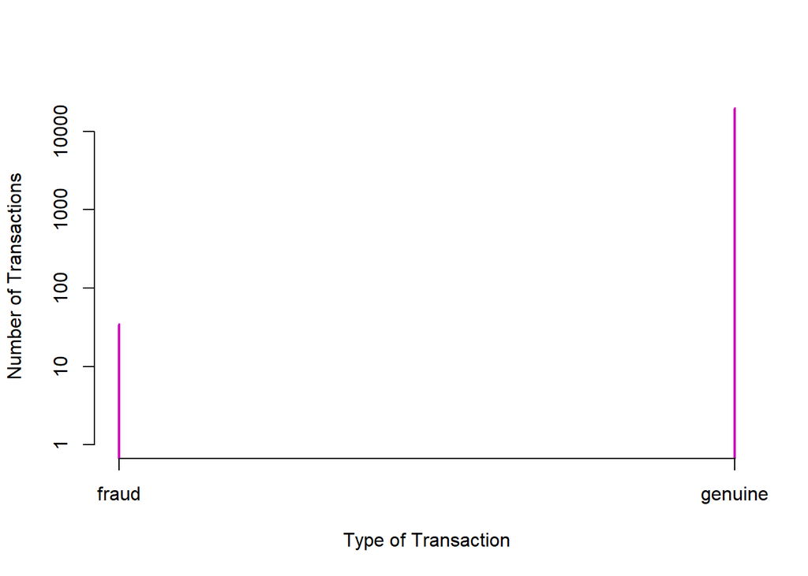

> There is a clear imbalance between, the fraud class and the genuine class. Next step is, Upsampling the Minority Class and Downsampling the Majority Class to Balance the Training Data. Now, looking at the Balanced Train Data

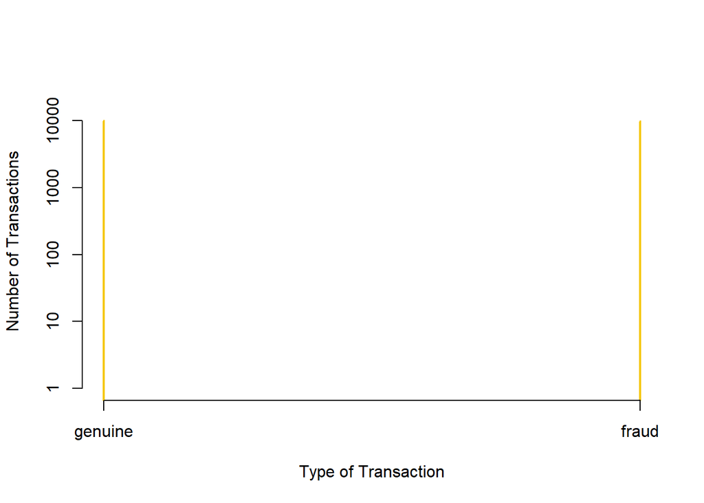

### Modeling

#### 1. K-Nearest Neighbours Classifier

Code : hdd_knn_mod = train(form = Class~., data = trn_smple, method = “knn”, trControl = cv_5, tuneLength = 15 )

Initial Results with Cross Validation:

```
##     k       ROC      Sens Spec        ROCSD      SensSD SpecSD
## 1   5 0.9990064 0.9851935    1 0.0008422889 0.002313451      0
## 2   7 0.9990064 0.9789331    1 0.0008422889 0.002471013      0
## 3   9 0.9990064 0.9728712    1 0.0008422889 0.002341892      0
## 4  11 0.9990064 0.9681009    1 0.0008422889 0.002685824      0
## 5  13 0.9990064 0.9623372    1 0.0008422889 0.003191659      0
## 6  15 0.9990064 0.9572693    1 0.0008422889 0.002532200      0
## 7  17 0.9990064 0.9520022    1 0.0008422889 0.003310492      0
## 8  19 0.9990064 0.9466359    1 0.0008422889 0.004830414      0
## 9  21 0.9990064 0.9410707    1 0.0008422889 0.004972812      0
## 10 23 0.9990064 0.9363010    1 0.0008422889 0.004510608      0
## 11 25 0.9990064 0.9326241    1 0.0008422889 0.004895348      0
## 12 27 0.9990064 0.9279531    1 0.0008422889 0.006297326      0
## 13 29 0.9990064 0.9226866    1 0.0008422889 0.004678663      0
## 14 31 0.9990064 0.9172213    1 0.0008422889 0.004660839      0
## 15 33 0.9990064 0.9099666    1 0.0008422889 0.005123139      0
```

#### 2. Decision Tree Classifier

Code: hd_tree_mod = train(form = Class~., data = trn_smple, method = “rpart”, trControl = cv_5, tuneLength = 15 )

Initial Results with Cross Validation:

```
##            cp       ROC      Sens      Spec        ROCSD       SensSD
## 1  0.00000000 0.9998225 0.9993045 1.0000000 0.0002367861 0.0005663844
## 2  0.06402478 0.9900262 0.9656169 1.0000000 0.0018220570 0.0041298436
## 3  0.12804957 0.9482815 0.9830078 0.9135553 0.0029972802 0.0035685979
## 4  0.19207435 0.9482815 0.9830078 0.9135553 0.0029972802 0.0035685979
## 5  0.25609914 0.9482815 0.9830078 0.9135553 0.0029972802 0.0035685979
## 6  0.32012392 0.9482815 0.9830078 0.9135553 0.0029972802 0.0035685979
## 7  0.38414871 0.9482815 0.9830078 0.9135553 0.0029972802 0.0035685979
## 8  0.44817349 0.9482815 0.9830078 0.9135553 0.0029972802 0.0035685979
## 9  0.51219828 0.9482815 0.9830078 0.9135553 0.0029972802 0.0035685979
## 10 0.57622306 0.9482815 0.9830078 0.9135553 0.0029972802 0.0035685979
## 11 0.64024785 0.9482815 0.9830078 0.9135553 0.0029972802 0.0035685979
## 12 0.70427263 0.9482815 0.9830078 0.9135553 0.0029972802 0.0035685979
## 13 0.76829742 0.9482815 0.9830078 0.9135553 0.0029972802 0.0035685979
## 14 0.83232220 0.9482815 0.9830078 0.9135553 0.0029972802 0.0035685979
```

[output cut: 17 more lines]

#### 3. Logistic Regression

Code : hd_glm_mod = train(form = Class~., data = trn_smple, method = “glm”, trControl = cv_5 )

Initial Results with Cross Validation:

```
##   parameter       ROC      Sens      Spec      ROCSD      SensSD     SpecSD
## 1      none 0.9761549 0.9925463 0.9486864 0.03052192 0.003785808 0.08632052
```

#### 4. Naive Bayes Classifier

hd_nb_mod = train(form = Class~., data = trn_smple, method = “naive_bayes”, trControl = cv_5 )

Initial Results with Cross Validation:

```
##   usekernel laplace adjust       ROC      Sens      Spec        ROCSD
## 1     FALSE       0      1 0.9917250 0.9743615 0.9209025 0.0009808351
## 2      TRUE       0      1 0.9974546 0.9918512 0.9094276 0.0003288432
##        SensSD      SpecSD
## 1 0.004453032 0.009441975
## 2 0.001432021 0.011529789
```

## Results

#### K Nearest Neighbours Classifier

```
## [1] "The Accuracy of KNN  Classifier is 0.914400"
```

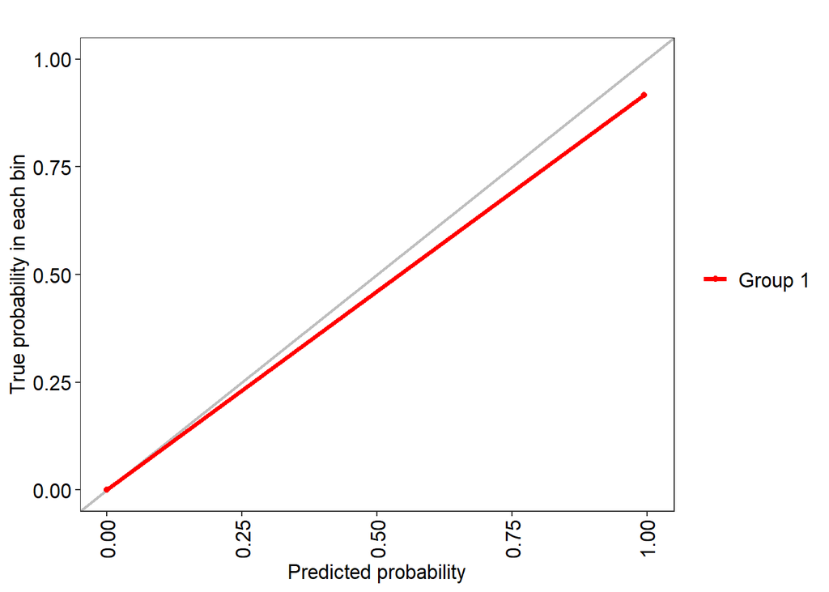

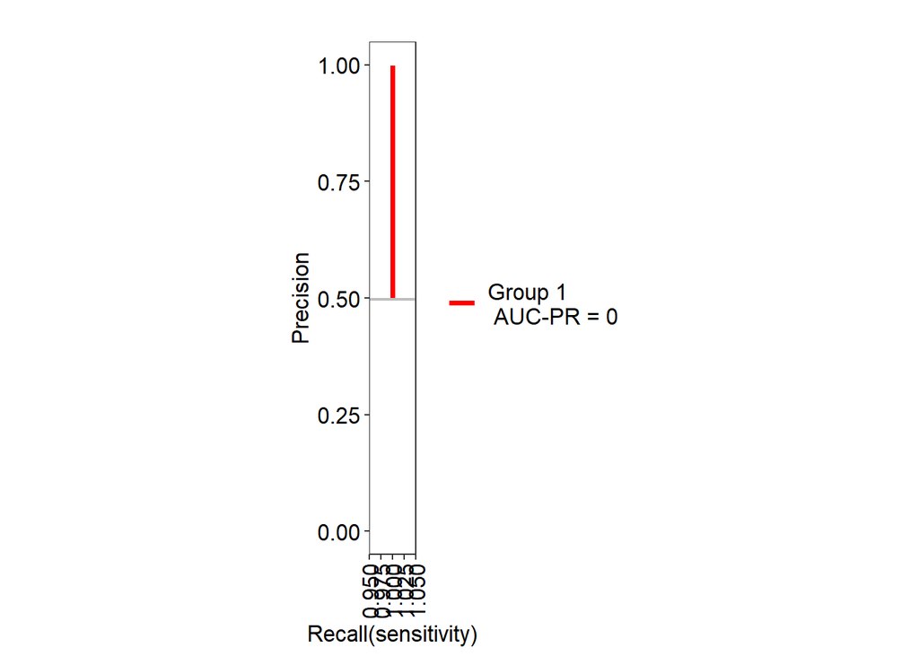

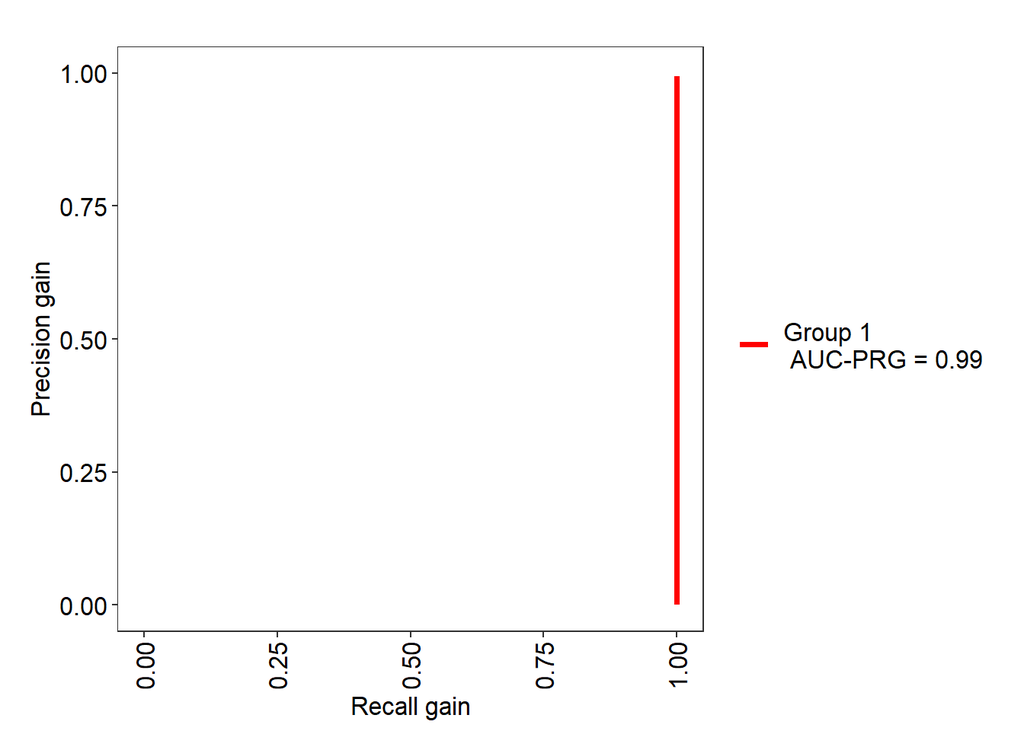

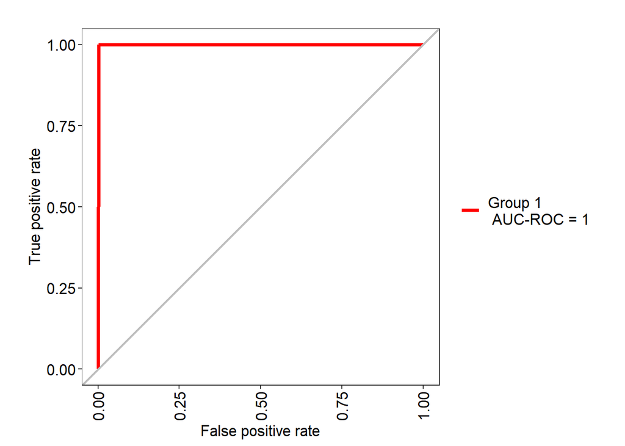

#### Decision Tree Classifier

```
## [1] "The Accuracy of Decision Tree Classifier is 0.999000:"
```

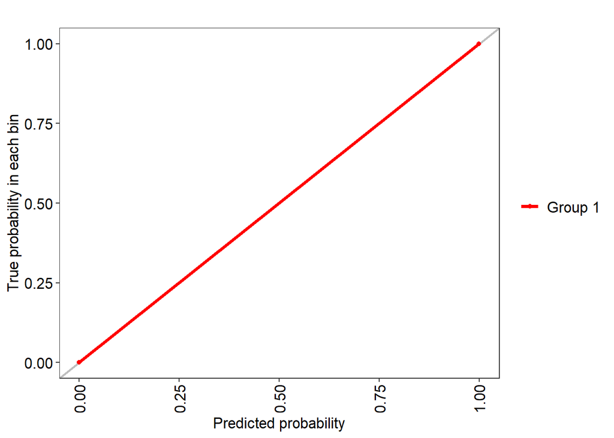

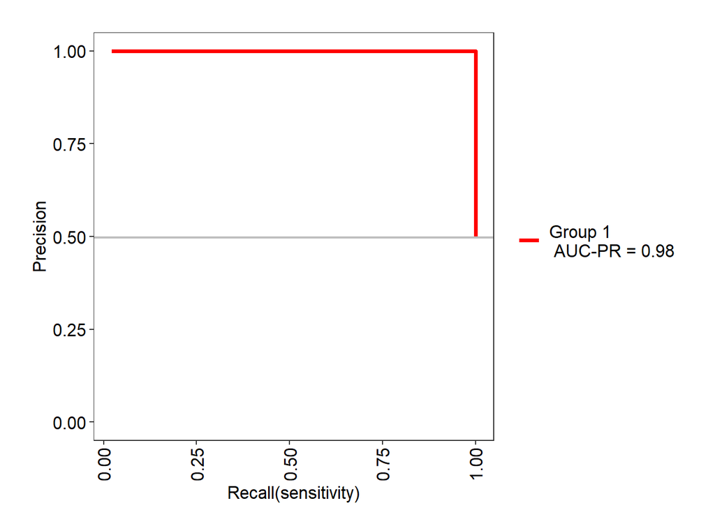

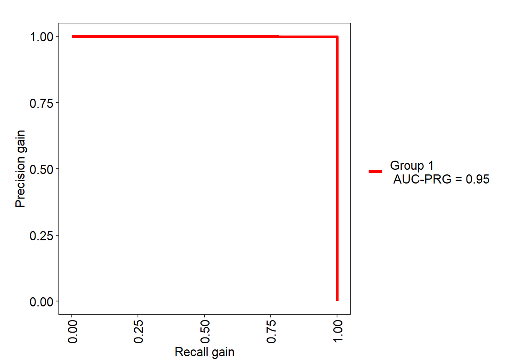

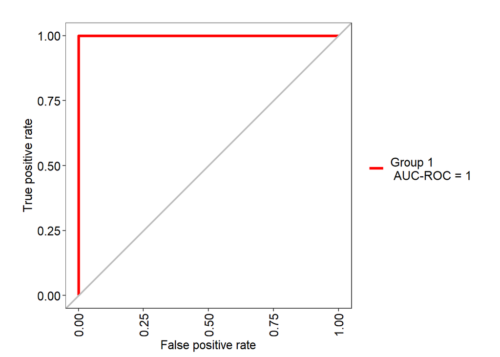

#### Logistic Regression Classifier

```
## [1] "The Accuracy of Logistic Regression is 0.987800"
```

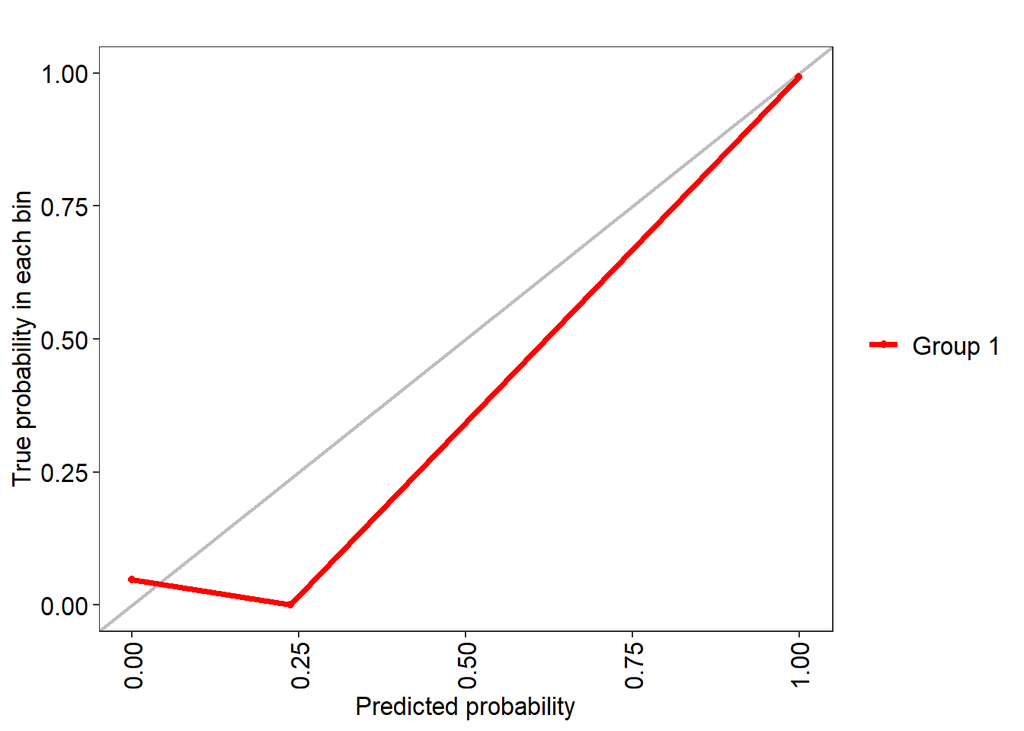

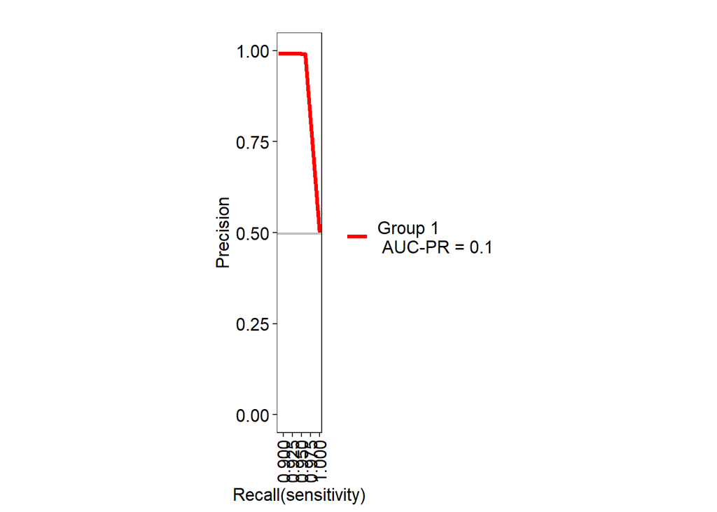

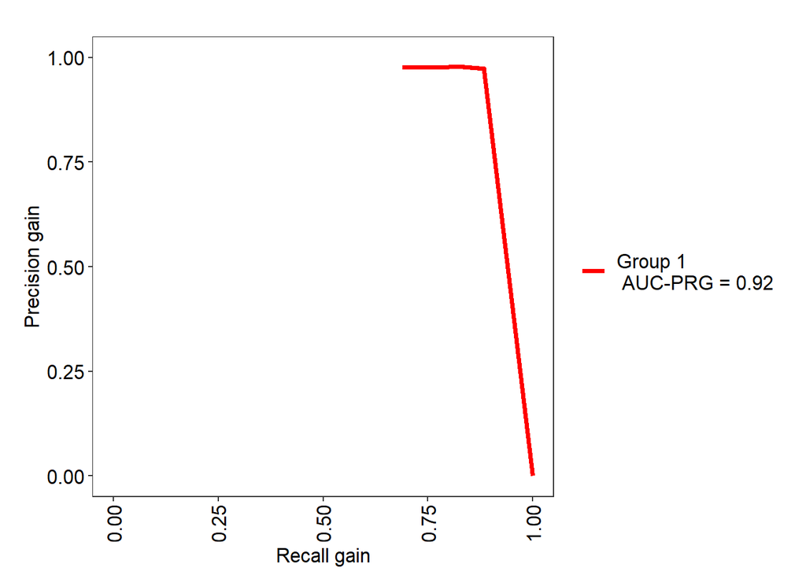

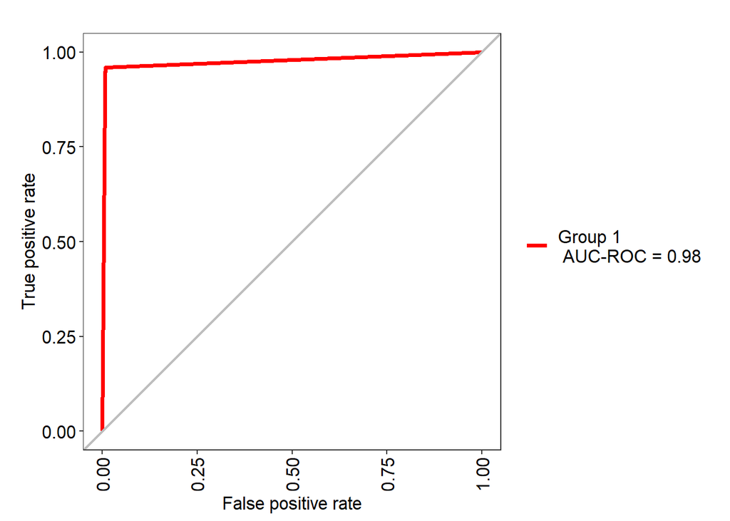

#### Naive Bayes Classifier

```
## [1] "The Accuracy of Naive Bayes Classifier is 0.990800"
```

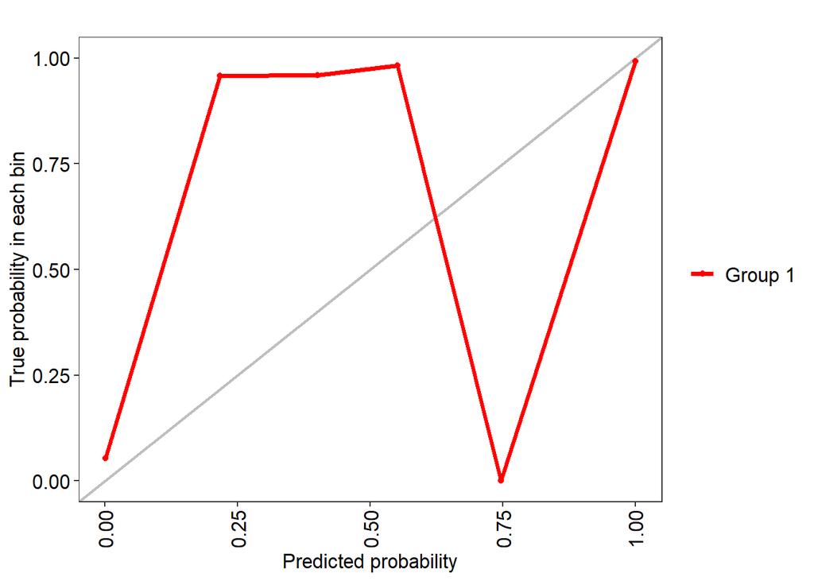

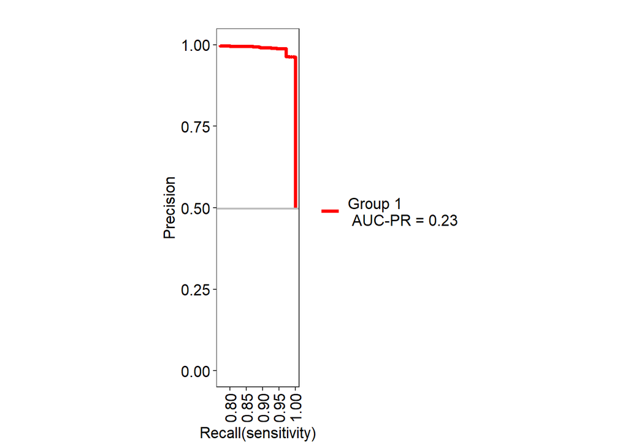

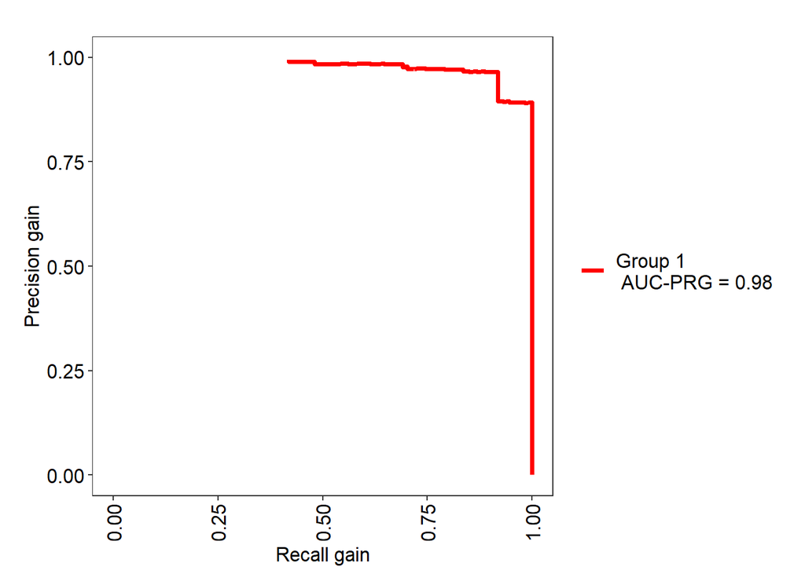

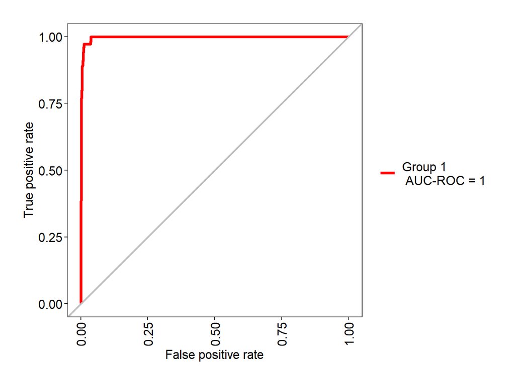

## Discussion

The decison tree classifier can be used as the final model. Talking about interpretation of these results, the metrics being used to compare different models in our case are Accuracy, AUC-ROC and AUC-PR.

## Appendix

Data Dictionary :

V1 - V28 : Features V1, V2, … V28 are the principal components obtained with PCA. Time : Feature ‘Time’ contains the seconds elapsed between each transaction and the first transaction in the dataset. Amount : The feature ‘Amount’ is the transaction Amount